# Unit 9 Lab Report

Christopher Byrd

2024-11-20

### Section 1: Hypothesis

The goal of this research paper is to determine if regular prayer has any correlation on the opinion of the federal government allowing prayer in school. The following are the hypothesizes examined:

> Null: There is no significant correlation between prayer frequency and opinion on prayer in school.  
> Research<sub>1</sub>: There will be a significance between prayer frequency and opinion on prayer in schools.

> H<sub>0</sub>: Higher prayer frequency ≠ Significance on opion of prayer in School  
> H<sub>1</sub>: Higher prayer frequency = Significance on opion of prayer in School

### Section 2: Data

The data used for this report is from the Baylor Survey of Religious Life. The answers of participants are encoded as follows:

| Question asked or description | Answers |
| --- | --- |
| About how much time do you | 0 - Never |
| spend praying alone outside | 1 - On certain occasions |
| of religious services? | 2 - Once a week or less |
|  | 3 - A few times a week |
|  | 4 - Once daily |
|  | 5 - Several times a day |
| ———————————— | ————————– |
| The federal government should | 1 - Strongly disagree |
| allow prayer in public school | 2 - Disagree |
|  | 3 - Agree |
|  | 4 - Strongly agree |
|  | 8 - Undecided |

The preceding data is nominal.

### Section 3: Method

Using RStudio, the data was imported from an excel sheet using the `readxl` package and directed into the variable `Module_9_Lab_Data`. To analyse the data, the function `CrossTable()` was run. It creates a cross tabulation table and runs a chi-squared test.

```r
CrossTable(Module_9_Lab_Data$PrayerFreq, Module_9_Lab_Data$PrayerSchool,
           expected = TRUE, dnn = c("Prayer Frequency",
                                    "Prayer in School"),
           format = c("SPSS"))
```

From here, a bar chart of opinions on prayer in school related to prayer habits was created. To do so was a bit of a task.

```r
data <- Module_9_Lab_Data

result <- data %>%
  group_by(PrayerFreq, PrayerSchool) %>%
  summarise(Count = n(), .groups = 'drop')

# View the result
print(result, n = 35)
```

[output not shown]

Then came the tedious part. I transcribed the amount of occurrences by hand to a `data.frame` capable of displaying the data in the graph. I’m not entirely certain why I had to use `rep()` on my Habit variable, other than RStudio threw an error saying that lengths between response and habit must be identical.

```r
# Data
data <- data.frame(
  Habit = rep(paste("Habit", 0:5), each = 5),
  Response = rep(c("Strongly Disagree", "Disagree", "Agree", "Strongly Agree", "Undecided"), times = 6),
  Count = c(117, 46, 39, 7, 15,   # Habit 0
            41, 56, 98, 35, 26,   # Habit 1
            9, 13, 40, 13, 9,     # Habit 2
            14, 26, 83, 55, 14,   # Habit 3
            17, 25, 108, 97, 20,  # Habit 4
            17, 26, 112, 198, 19) # Habit 5
)
```

Finally, here’s the graph code, with one quick addon: originally, the responses were displayed without a logical order. They had to be manually coerced to display in the order desired using a `factor()`.

```r
# Reordering Response levels
data$Response <- factor(data$Response,
                        levels = c("Undecided", "Strongly Disagree", "Disagree", "Agree", "Strongly Agree"))

# Create the plot
ggplot(data, aes(x = Response, y = Count, fill = Response)) +
  geom_bar(stat = "identity") +
  facet_wrap(~ Habit, scales = "free_y") +
  labs(
    title = "Survey Responses for Prayer Habits",
    x = "Prayer should be allowed in public schools",
    y = "Count") +
  theme(
    axis.text.x = element_blank()
    ) +
  scale_fill_manual(values = c("#787878", "#ff1100",
                               "#ff6961", "#92ff8c", "#0dff00"))
```

Note that the y-axis are *intentionally* different in each graph in figure 1. This is to better illustrate relationships in the graphs rather than just raw numbers. Figure 2 offers an un-adjusted view for better transparency on raw numbers.

### Section 4: Results

The results from `CrossTable()` can be viewed in full in figure 3. As for the results of the Chi-squared test (fig. 4), it returns a p-value of 1.06E-89, well into statistical significance. This is further demonstrated in figure 1.

### Section 5: Discussion and Conclusion

It stands to reason the null is rejected and H<sub>1</sub> is accepted.

### Section 6: Graphics and Visuals

*Note formatting in this section is weird due to figure size.*

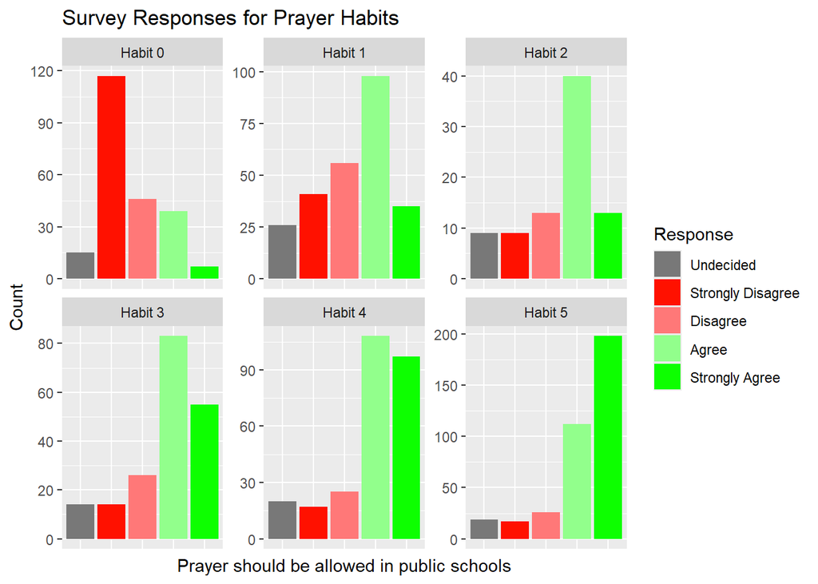

Bar graph with adjusted Y-value. Opinion on prayer in public school based upon prayer habit.

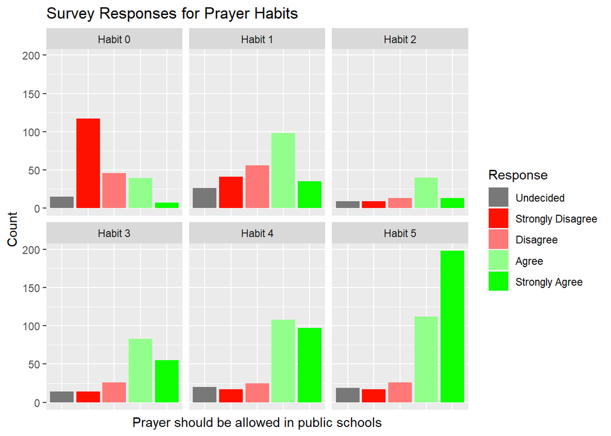

Bar graph with non-adjusted Y-value. Opinion on prayer in public school based upon prayer habit.

| Prayer Opinion: | 1 | 2 | 3 | 4 | 8 |  |
| --- | --- | --- | --- | --- | --- | --- |
| Prayer Frequency |  |  |  |  |  | Row Total |
| —————– |  |  |  |  |  | ———– |
| 0 | 117 | 46 | 39 | 7 | 15 | 224 |
|  | 34.523 | 30.830 | 77.075 | 65.032 | 16.539 |  |
|  | 197.038 | 7.464 | 18.809 | 51.786 | 0.143 |  |
|  | 52.232% | 20.536% | 17.411% | 3.125% | 6.696% | 16.057% |
|  | 54.419% | 23.958% | 8.125% | 1.728% | 14.563% |  |
|  | 8.387% | 3.297% | 2.796% | 0.502% | 1.075% |  |
| —————– | ———– | ———– | ———– | ———– | ———– | ———– |
| 1 | 41 | 56 | 98 | 35 | 26 | 256 |
|  | 39.455 | 35.234 | 88.086 | 74.323 | 18.902 |  |
|  | 0.060 | 12.238 | 1.116 | 20.805 | 2.666 |  |
|  | 16.016% | 21.875% | 38.281% | 13.672% | 10.156% | 18.351% |
|  | 19.070% | 29.167% | 20.417% | 8.642% | 25.243% |  |
|  | 2.939% | 4.014% | 7.025% | 2.509% | 1.864% |  |
| —————– | ———– | ———– | ———– | ———– | ———– | ———– |
| 2 | 9 | 13 | 40 | 13 | 9 | 84 |
|  | 12.946 | 11.561 | 28.903 | 24.387 | 6.202 |  |
|  | 1.203 | 0.179 | 4.260 | 5.317 | 1.262 |  |
|  | 10.714% | 15.476% | 47.619% | 15.476% | 10.714% | 6.022% |
|  | 4.186% | 6.771% | 8.333% | 3.210% | 8.738% |  |
|  | 0.645% | 0.932% | 2.867% | 0.932% | 0.645% |  |
| —————– | ———– | ———– | ———– | ———– | ———– | ———– |
| 3 | 14 | 26 | 83 | 55 | 14 | 192 |
|  | 29.591 | 26.426 | 66.065 | 55.742 | 14.176 |  |
|  | 8.215 | 0.007 | 4.341 | 0.010 | 0.002 |  |
|  | 7.292% | 13.542% | 43.229% | 28.646% | 7.292% | 13.763% |
|  | 6.512% | 13.542% | 17.292% | 13.580% | 13.592% |  |
|  | 1.004% | 1.864% | 5.950% | 3.943% | 1.004% |  |
| —————– | ———– | ———– | ———– | ———– | ———– | ———– |
| 4 | 17 | 25 | 108 | 97 | 20 | 267 |
|  | 41.151 | 36.748 | 91.871 | 77.516 | 19.714 |  |
|  | 14.174 | 3.756 | 2.832 | 4.897 | 0.004 |  |
|  | 6.367% | 9.363% | 40.449% | 36.330% | 7.491% | 19.140% |
|  | 7.907% | 13.021% | 22.500% | 23.951% | 19.417% |  |
|  | 1.219% | 1.792% | 7.742% | 6.953% | 1.434% |  |
| —————– | ———– | ———– | ———– | ———– | ———– | ———– |
| 5 | 17 | 26 | 112 | 198 | 19 | 372 |
|  | 57.333 | 51.200 | 128.000 | 108.000 | 27.467 |  |
|  | 28.374 | 12.403 | 2.000 | 75.000 | 2.610 |  |
|  | 4.570% | 6.989% | 30.108% | 53.226% | 5.108% | 26.667% |
|  | 7.907% | 13.542% | 23.333% | 48.889% | 18.447% |  |
|  | 1.219% | 1.864% | 8.029% | 14.194% | 1.362% |  |
| —————– | ———– | ———– | ———– | ———– | ———– | ———– |
| Column Total | 215 | 192 | 480 | 405 | 103 | 1395 |
|  | 15.412% | 13.763% | 34.409% | 29.032% | 7.384% |  |
| —————– | ———– | ———– | ———– | ———– | ———– | ———– |

Figure 3. Cross tabulation table.

| Pearson’s Chi-squared test |  |  |
| --- | --- | --- |
| Chi^2 = 482.9719 | d.f. = 20 | p = 1.063345e-89 |

Figure 4. Chart. Pearson’s chi-squared test.